# Homework 3

In the third homework, I have expected to perform regression and try to determine future consumption on the electricity in Turkey. Here the data that I have used. I have extract the day and hour values as integer to work on the data easier.

```r
library(data.table)
consumption<-read.csv("consumptiondata.csv")
```

```r
head(consumption)
```

A data.frame: 6 × 3

| Tarih <fct> | Saat <fct> | Tüketim.Miktarı..MWh. <fct> |
| --- | --- | --- |
| 01.01.2016 | 00:00 | 26.277,24 |
| 01.01.2016 | 01:00 | 24.991,82 |
| 01.01.2016 | 02:00 | 23.532,61 |
| 01.01.2016 | 03:00 | 22.464,78 |
| 01.01.2016 | 04:00 | 22.002,91 |
| 01.01.2016 | 05:00 | 21.957,08 |

```r
index<-as.integer(1)
for (i in 1:33600){
    if(i==1){
        consumption$day[i]<-1
    }
    else if(consumption$Tarih[i]!=consumption$Tarih[i-1]){
        index<-index+1
        consumption$day[i]<-index

    }
        else{
           consumption$day[i]<-index
        }
}
```

```r
consumption$hour<-as.integer(consumption$Saat)
```

```r
consumption_train_data<-consumption[consumption$day <1400,]
```

## Part a)

In part a, I have taken the data of last two days (day 1398, 1399) and treat them as the forecasts of the next two days (day 1400 Nov 1 and day 1401 Nov 2). Then I have tested these results on the table for the 48-lag values. I have the same calculation on the 168-lag values.

```r
consumption_forecasts_lag48<-consumption_train_data[consumption_train_data$day>1397,3:5]
consumption_forecasts_lag48$day<-consumption_forecasts_lag48$day+2
```

```r
consumption_forecasts_lag168<-consumption_train_data[consumption_train_data$day>1392,3:5]
consumption_forecasts_lag168$day<-consumption_forecasts_lag168$day+7
```

```r
library(data.table)
consumption_test_data<-read.csv("testdataconsumption.csv")
index<-as.integer(1)
for (i in 1:408){
    if(i==1){
        consumption_test_data$day[i]<-1
    }
    else if(consumption_test_data$Tarih[i]!=consumption_test_data$Tarih[i-1]){
        index<-index+1
        consumption_test_data$day[i]<-index

    }
        else{
           consumption_test_data$day[i]<-index
        }
}
consumption_test_data$hour<-as.integer(consumption_test_data$Saat)
```

```r
results_lag48<-consumption_test_data[consumption_test_data$day<3,]
results_lag48$forecasts<-consumption_forecasts_lag48$Tüketim.Miktarı..MWh.
```

```r
results_lag48$actual <- gsub("\\.", "", results_lag48$Tüketim.Miktarı..MWh.)
results_lag48$actual_real <- gsub("\\,", ".", results_lag48$actual)
```

```r
results_lag48$forecasts2 <- gsub("\\.", "", results_lag48$forecasts)
results_lag48$forecasts_real <- gsub("\\,", ".", results_lag48$forecasts2)
results_lag48$actual_real<-as.numeric(results_lag48$actual_real)
results_lag48$forecasts_real<-as.numeric(results_lag48$forecasts_real)
```

```r
results_lag48$APE<- abs((results_lag48$actual_real-results_lag48$forecasts_real)/results_lag48$actual_real)*100
```

```r
head(results_lag48)
```

A data.frame: 6 × 11

| Tarih <fct> | Saat <fct> | Tüketim.Miktarı..MWh. <fct> | day <dbl> | hour <int> | forecasts <fct> | actual <chr> | actual_real <dbl> | forecasts2 <chr> | forecasts_real <dbl> | APE <dbl> |
| --- | --- | --- | --- | --- | --- | --- | --- | --- | --- | --- |
| 01.11.2019 | 00:00 | 29.417,56 | 1 | 1 | 27.154,21 | 29417,56 | 29417.56 | 27154,21 | 27154.21 | 7.693874 |
| 01.11.2019 | 01:00 | 28.133,75 | 1 | 2 | 26.157,42 | 28133,75 | 28133.75 | 26157,42 | 26157.42 | 7.024766 |
| 01.11.2019 | 02:00 | 27.358,60 | 1 | 3 | 25.373,88 | 27358,60 | 27358.60 | 25373,88 | 25373.88 | 7.254465 |
| 01.11.2019 | 03:00 | 26.780,09 | 1 | 4 | 24.911,43 | 26780,09 | 26780.09 | 24911,43 | 24911.43 | 6.977796 |
| 01.11.2019 | 04:00 | 26.511,54 | 1 | 5 | 24.836,11 | 26511,54 | 26511.54 | 24836,11 | 24836.11 | 6.319625 |
| 01.11.2019 | 05:00 | 27.002,74 | 1 | 6 | 25.233,76 | 27002,74 | 27002.74 | 25233,76 | 25233.76 | 6.551113 |

```r
for (i in 1:24){
MAPE_lag48[i]<-mean(results_lag48$APE[results_lag48$hour==i])
    }

MAPE_lag48
```

1. 4.23803675703283

2. 3.76837882220548

3. 3.86553847412877

4. 3.7983331536597

5. 3.41538568987317

6. 3.82906924244881

7. 4.55670050354571

8. 5.15912966284927

9. 6.01996886565056

10. 5.18864136310459

11. 5.71415590927145

12. 5.23216291438291

13. 4.18080927080843

14. 5.1673909531862

15. 8.46759542262737

16. 8.77953082307995

17. 8.04141662580064

18. 6.16393786902728

19. 3.49332184154316

20. 2.32685064090641

21. 2.201846502296

22. 2.2024701555657

23. 1.73975083749142

24. 1.9045081722481

```r
results_lag168<-consumption_test_data[consumption_test_data$day<8,]
results_lag168$forecasts<-consumption_forecasts_lag168$Tüketim.Miktarı..MWh.
results_lag168$actual <- gsub("\\.", "", results_lag168$Tüketim.Miktarı..MWh.)
results_lag168$actual_real <- gsub("\\,", ".", results_lag168$actual)
results_lag168$forecasts2 <- gsub("\\.", "", results_lag168$forecasts)
results_lag168$forecasts_real <- gsub("\\,", ".", results_lag168$forecasts2)
results_lag168$actual_real<-as.numeric(results_lag168$actual_real)
results_lag168$forecasts_real<-as.numeric(results_lag168$forecasts_real)
results_lag168$APE<- abs((results_lag168$actual_real-results_lag168$forecasts_real)/results_lag168$actual_real)*100

MAPE_lag168<-as.vector(1:24)
for (i in 1:24){
MAPE_lag168[i]<-mean(results_lag168$APE[results_lag168$hour==i])
    }
MAPE_lag168
```

1. 4.69912510215056

2. 4.47525670399892

3. 4.6580715612544

4. 4.55942488402078

5. 4.56422900374468

6. 4.75307372373036

7. 5.21297021075755

8. 6.23048513088769

9. 5.47720098860018

10. 5.18753142931968

11. 4.70235601339213

12. 4.61126412788759

13. 4.6984594905549

14. 5.06676930184387

15. 5.50716066127048

16. 5.39596790322033

17. 5.16001247352092

18. 4.94017946076908

19. 4.70219869746672

20. 4.26548071842221

21. 4.44473754236529

22. 4.52984592257841

23. 4.98956456775928

24. 5.16435125552974

```r
MAPE_lag48/MAPE_lag168
```

1. 0.901877831491075

2. 0.842047522958448

3. 0.829858112589363

4. 0.833072865608895

5. 0.74829411212081

6. 0.805598537916983

7. 0.874108295140924

8. 0.828046220232969

9. 1.09909584807643

10. 1.00021396184294

11. 1.21516871393781

12. 1.13464828066133

13. 0.889825543715536

14. 1.0198591341638

15. 1.53756099439342

16. 1.62705393741136

17. 1.55841030754594

18. 1.24771537511467

19. 0.742912425930696

20. 0.545507246312698

21. 0.495382793991538

22. 0.486213039738898

23. 0.348677888393917

24. 0.36877975141773

## Part b)

```r
consumption_train_data$actual <- gsub("\\.", "", consumption_train_data$Tüketim.Miktarı..MWh.)
consumption_train_data$actual_real <- gsub("\\,", ".", consumption_train_data$actual)
```

```r
consumption_values<-consumption_train_data[,c(1,4,5,7)]
```

```r
for (i in 1:(24*1399))
     {
    if(i<49){
        consumption_values$lag_48[i]<-0
        consumption_values$lag_168[i]<-0
        }
    else if(i>=49 && i<=168){
        consumption_values$lag_168[i]<-0
        consumption_values$lag_48[i]<-consumption_values$actual_real[i-48]
        }
    else{
        consumption_values$lag_168[i]<-consumption_values$actual_real[i-168]
        consumption_values$lag_48[i]<-consumption_values$actual_real[i-48]
        }
    }
```

```r
consumption_values_long<-consumption_values
```

```r
lmdata<-consumption_values_long[169:(24*1399),]
lmdata$actual_real<-as.integer(lmdata$actual_real)
lmdata$lag_48<-as.numeric(lmdata$lag_48)
lmdata$lag_168<-as.numeric(lmdata$lag_168)
```

```r
head(lmdata)
```

A data.frame: 6 × 6

|  | Tarih <fct> | day <dbl> | hour <int> | actual_real <int> | lag_48 <dbl> | lag_168 <dbl> |
| --- | --- | --- | --- | --- | --- | --- |
| 169 | 08.01.2016 | 8 | 1 | 28602 | 29189.27 | 26277.24 |
| 170 | 08.01.2016 | 8 | 2 | 27112 | 27614.02 | 24991.82 |
| 171 | 08.01.2016 | 8 | 3 | 25975 | 26578.97 | 23532.61 |
| 172 | 08.01.2016 | 8 | 4 | 25315 | 25719.19 | 22464.78 |
| 173 | 08.01.2016 | 8 | 5 | 25128 | 25864.63 | 22002.91 |
| 174 | 08.01.2016 | 8 | 6 | 25356 | 25918.59 | 21957.08 |

```r
consumption_test_data<-consumption_test_data[1:(16*24),]
consumption_test_data$actual <- gsub("\\.", "", consumption_test_data$Tüketim.Miktarı..MWh.)
consumption_test_data$actual_real <- gsub("\\,", ".", consumption_test_data$actual)
consumption_test_data$actual_real<-as.numeric(consumption_test_data$actual_real)
```

```r
for (i in 1:(16*24)){
    if(i<=48){
        consumption_test_data$lag_48[i]<-consumption_values_long$actual_real[i+1397*24]
        consumption_test_data$lag_168[i]<-consumption_values_long$actual_real[i+1392*24]
             }
    else if(i>48 && i<=168){
        consumption_test_data$lag_48[i]<-consumption_test_data$actual_real[i-48]
        consumption_test_data$lag_168[i]<-consumption_values_long$actual_real[i+1392*24]
             }
        else {
        consumption_test_data$lag_48[i]<-consumption_test_data$actual_real[i-48]
        consumption_test_data$lag_168[i]<-consumption_test_data$actual_real[i-168]
             }
        }
```

```r
consumption_test_data$lag_48<-as.numeric(consumption_test_data$lag_48)
consumption_test_data$lag_168<-as.numeric(consumption_test_data$lag_168)
```

```r
consumption_test_data_for_part_b<-consumption_test_data
```

```r
linearmodelforallvaluesforhour1<-lm(actual_real~lag_48+lag_168,data=lmdata[lmdata$hour==1,])
linearmodelforallvalues<-lm(actual_real~lag_48+lag_168,data=lmdata)
```

```r
summary(linearmodelforallvaluesforhour1)
summary(linearmodelforallvalues)
```

```
Call:
lm(formula = actual_real ~ lag_48 + lag_168, data = lmdata[lmdata$hour ==
    1, ])

Residuals:
    Min      1Q  Median      3Q     Max
-9082.7  -773.9    41.5   868.3  6257.2

Coefficients:
             Estimate Std. Error t value Pr(>|t|)
(Intercept) 2.395e+03  5.078e+02   4.717 2.64e-06 ***
lag_48      5.028e-01  1.912e-02  26.291  < 2e-16 ***
lag_168     4.199e-01  1.911e-02  21.973  < 2e-16 ***
---
Signif. codes:  0 '***' 0.001 '**' 0.01 '*' 0.05 '.' 0.1 ' ' 1

Residual standard error: 1604 on 1389 degrees of freedom
Multiple R-squared:  0.6971,	Adjusted R-squared:  0.6967
F-statistic:  1599 on 2 and 1389 DF,  p-value: < 2.2e-16
```

```
Call:
lm(formula = actual_real ~ lag_48 + lag_168, data = lmdata)

Residuals:
     Min       1Q   Median       3Q      Max
-16784.5   -994.3      2.7   1022.3  15951.0

Coefficients:
             Estimate Std. Error t value Pr(>|t|)
(Intercept) 1.623e+03  9.678e+01   16.77   <2e-16 ***
lag_48      3.257e-01  3.520e-03   92.51   <2e-16 ***
lag_168     6.246e-01  3.518e-03  177.51   <2e-16 ***
---
Signif. codes:  0 '***' 0.001 '**' 0.01 '*' 0.05 '.' 0.1 ' ' 1

Residual standard error: 2403 on 33405 degrees of freedom
Multiple R-squared:  0.7627,	Adjusted R-squared:  0.7627
F-statistic: 5.368e+04 on 2 and 33405 DF,  p-value: < 2.2e-16
```

```r
consumption_test_data_for_part_b$forecasts<-linearmodelforallvalues$coefficients[1]+linearmodelforallvalues$coefficients[2]*consumption_test_data_for_part_b$lag_48+linearmodelforallvalues$coefficients[3]*consumption_test_data_for_part_b$lag_168
```

```r
consumption_test_data_for_part_b$APE<-abs((consumption_test_data_for_part_b$actual_real-consumption_test_data_for_part_b$forecasts)/consumption_test_data_for_part_b$actual_real)*100
```

```r
mean(consumption_test_data_for_part_b$APE)
```

3.92816799427263

## Part c)

In this part, I have taken the all hour levels for 7 days and 2 days before values as the predictors.

```r
lmdata_hour1<-lmdata[lmdata$hour==1,]
lmdata_hour2<-lmdata[lmdata$hour==2,]
lmdata_hour3<-lmdata[lmdata$hour==3,]
lmdata_hour4<-lmdata[lmdata$hour==4,]
lmdata_hour5<-lmdata[lmdata$hour==5,]
lmdata_hour6<-lmdata[lmdata$hour==6,]
lmdata_hour7<-lmdata[lmdata$hour==7,]
lmdata_hour8<-lmdata[lmdata$hour==8,]
lmdata_hour9<-lmdata[lmdata$hour==9,]
lmdata_hour10<-lmdata[lmdata$hour==10,]
lmdata_hour11<-lmdata[lmdata$hour==11,]
lmdata_hour12<-lmdata[lmdata$hour==12,]
lmdata_hour13<-lmdata[lmdata$hour==13,]
lmdata_hour14<-lmdata[lmdata$hour==14,]
lmdata_hour15<-lmdata[lmdata$hour==15,]
lmdata_hour16<-lmdata[lmdata$hour==16,]
lmdata_hour17<-lmdata[lmdata$hour==17,]
lmdata_hour18<-lmdata[lmdata$hour==18,]
lmdata_hour19<-lmdata[lmdata$hour==19,]
lmdata_hour20<-lmdata[lmdata$hour==20,]
lmdata_hour21<-lmdata[lmdata$hour==21,]
lmdata_hour22<-lmdata[lmdata$hour==22,]
lmdata_hour23<-lmdata[lmdata$hour==23,]
lmdata_hour24<-lmdata[lmdata$hour==24,]
```

```r
linearmodel_hour1<-lm(actual_real~lag_48+lag_168,data=lmdata_hour1)
linearmodel_hour2<-lm(actual_real~lag_48+lag_168,data=lmdata_hour2)
linearmodel_hour3<-lm(actual_real~lag_48+lag_168,data=lmdata_hour3)
linearmodel_hour4<-lm(actual_real~lag_48+lag_168,data=lmdata_hour4)
linearmodel_hour5<-lm(actual_real~lag_48+lag_168,data=lmdata_hour5)
linearmodel_hour6<-lm(actual_real~lag_48+lag_168,data=lmdata_hour6)
linearmodel_hour7<-lm(actual_real~lag_48+lag_168,data=lmdata_hour7)
linearmodel_hour8<-lm(actual_real~lag_48+lag_168,data=lmdata_hour8)
linearmodel_hour9<-lm(actual_real~lag_48+lag_168,data=lmdata_hour9)
linearmodel_hour10<-lm(actual_real~lag_48+lag_168,data=lmdata_hour10)
linearmodel_hour11<-lm(actual_real~lag_48+lag_168,data=lmdata_hour11)
linearmodel_hour12<-lm(actual_real~lag_48+lag_168,data=lmdata_hour12)
linearmodel_hour13<-lm(actual_real~lag_48+lag_168,data=lmdata_hour13)
linearmodel_hour14<-lm(actual_real~lag_48+lag_168,data=lmdata_hour14)
linearmodel_hour15<-lm(actual_real~lag_48+lag_168,data=lmdata_hour15)
linearmodel_hour16<-lm(actual_real~lag_48+lag_168,data=lmdata_hour16)
linearmodel_hour17<-lm(actual_real~lag_48+lag_168,data=lmdata_hour17)
linearmodel_hour18<-lm(actual_real~lag_48+lag_168,data=lmdata_hour18)
linearmodel_hour19<-lm(actual_real~lag_48+lag_168,data=lmdata_hour19)
linearmodel_hour20<-lm(actual_real~lag_48+lag_168,data=lmdata_hour20)
linearmodel_hour21<-lm(actual_real~lag_48+lag_168,data=lmdata_hour21)
linearmodel_hour22<-lm(actual_real~lag_48+lag_168,data=lmdata_hour22)
linearmodel_hour23<-lm(actual_real~lag_48+lag_168,data=lmdata_hour23)
linearmodel_hour24<-lm(actual_real~lag_48+lag_168,data=lmdata_hour24)
```

```r
summary(linearmodel_hour1)
summary(linearmodel_hour3)
summary(linearmodel_hour8)
summary(linearmodel_hour15)
summary(linearmodel_hour20)
```

```
Call:
lm(formula = actual_real ~ lag_48 + lag_168, data = lmdata_hour1)

Residuals:
    Min      1Q  Median      3Q     Max
-9082.7  -773.9    41.5   868.3  6257.2

Coefficients:
             Estimate Std. Error t value Pr(>|t|)
(Intercept) 2.395e+03  5.078e+02   4.717 2.64e-06 ***
lag_48      5.028e-01  1.912e-02  26.291  < 2e-16 ***
lag_168     4.199e-01  1.911e-02  21.973  < 2e-16 ***
---
Signif. codes:  0 '***' 0.001 '**' 0.01 '*' 0.05 '.' 0.1 ' ' 1

Residual standard error: 1604 on 1389 degrees of freedom
Multiple R-squared:  0.6971,	Adjusted R-squared:  0.6967
F-statistic:  1599 on 2 and 1389 DF,  p-value: < 2.2e-16
```

```
Call:
lm(formula = actual_real ~ lag_48 + lag_168, data = lmdata_hour3)

Residuals:
    Min      1Q  Median      3Q     Max
-9087.8  -799.1    62.3   860.4  6172.5

Coefficients:
             Estimate Std. Error t value Pr(>|t|)
(Intercept) 2.377e+03  4.797e+02   4.955  8.1e-07 ***
lag_48      5.088e-01  1.924e-02  26.452  < 2e-16 ***
lag_168     4.072e-01  1.921e-02  21.199  < 2e-16 ***
---
Signif. codes:  0 '***' 0.001 '**' 0.01 '*' 0.05 '.' 0.1 ' ' 1

Residual standard error: 1558 on 1389 degrees of freedom
Multiple R-squared:  0.6798,	Adjusted R-squared:  0.6793
F-statistic:  1474 on 2 and 1389 DF,  p-value: < 2.2e-16
```

```
Call:
lm(formula = actual_real ~ lag_48 + lag_168, data = lmdata_hour8)

Residuals:
    Min      1Q  Median      3Q     Max
-8796.7  -805.1    81.3   958.7  8808.5

Coefficients:
             Estimate Std. Error t value Pr(>|t|)
(Intercept) 2.935e+03  6.080e+02   4.828 1.53e-06 ***
lag_48      2.656e-01  1.839e-02  14.443  < 2e-16 ***
lag_168     6.315e-01  1.836e-02  34.397  < 2e-16 ***
---
Signif. codes:  0 '***' 0.001 '**' 0.01 '*' 0.05 '.' 0.1 ' ' 1

Residual standard error: 1940 on 1389 degrees of freedom
Multiple R-squared:  0.5821,	Adjusted R-squared:  0.5815
F-statistic: 967.5 on 2 and 1389 DF,  p-value: < 2.2e-16
```

```
Call:
lm(formula = actual_real ~ lag_48 + lag_168, data = lmdata_hour15)

Residuals:
     Min       1Q   Median       3Q      Max
-15994.6  -1518.9     -6.9   1670.0  15347.0

Coefficients:
             Estimate Std. Error t value Pr(>|t|)
(Intercept) 4.434e+03  8.223e+02   5.392 8.19e-08 ***
lag_48      2.747e-01  1.922e-02  14.293  < 2e-16 ***
lag_168     6.005e-01  1.925e-02  31.190  < 2e-16 ***
---
Signif. codes:  0 '***' 0.001 '**' 0.01 '*' 0.05 '.' 0.1 ' ' 1

Residual standard error: 3162 on 1389 degrees of freedom
Multiple R-squared:   0.53,	Adjusted R-squared:  0.5293
F-statistic: 783.2 on 2 and 1389 DF,  p-value: < 2.2e-16
```

```
Call:
lm(formula = actual_real ~ lag_48 + lag_168, data = lmdata_hour20)

Residuals:
     Min       1Q   Median       3Q      Max
-11607.9  -1020.9     58.3   1098.7   9034.2

Coefficients:
             Estimate Std. Error t value Pr(>|t|)
(Intercept) 3.791e+03  7.161e+02   5.294 1.39e-07 ***
lag_48      3.923e-01  1.946e-02  20.164  < 2e-16 ***
lag_168     5.014e-01  1.945e-02  25.775  < 2e-16 ***
---
Signif. codes:  0 '***' 0.001 '**' 0.01 '*' 0.05 '.' 0.1 ' ' 1

Residual standard error: 2073 on 1389 degrees of freedom
Multiple R-squared:  0.5903,	Adjusted R-squared:  0.5897
F-statistic:  1000 on 2 and 1389 DF,  p-value: < 2.2e-16
```

```r
for (j in 1:16){
    consumption_test_data$forecasts[24*(j-1)+1]<-linearmodel_hour1$coefficients[1]+linearmodel_hour1$coefficients[2]*consumption_test_data$lag_48[24*(j-1)+1]+linearmodel_hour1$coefficients[3]*consumption_test_data$lag_168[24*(j-1)+1]
    consumption_test_data$forecasts[24*(j-1)+2]<-linearmodel_hour2$coefficients[1]+linearmodel_hour2$coefficients[2]*consumption_test_data$lag_48[24*(j-1)+2]+linearmodel_hour1$coefficients[3]*consumption_test_data$lag_168[24*(j-1)+2]
    consumption_test_data$forecasts[24*(j-1)+3]<-linearmodel_hour3$coefficients[1]+linearmodel_hour3$coefficients[2]*consumption_test_data$lag_48[24*(j-1)+3]+linearmodel_hour1$coefficients[3]*consumption_test_data$lag_168[24*(j-1)+3]
    consumption_test_data$forecasts[24*(j-1)+4]<-linearmodel_hour4$coefficients[1]+linearmodel_hour4$coefficients[2]*consumption_test_data$lag_48[24*(j-1)+4]+linearmodel_hour1$coefficients[3]*consumption_test_data$lag_168[24*(j-1)+4]
    consumption_test_data$forecasts[24*(j-1)+5]<-linearmodel_hour5$coefficients[1]+linearmodel_hour5$coefficients[2]*consumption_test_data$lag_48[24*(j-1)+5]+linearmodel_hour1$coefficients[3]*consumption_test_data$lag_168[24*(j-1)+5]
    consumption_test_data$forecasts[24*(j-1)+6]<-linearmodel_hour6$coefficients[1]+linearmodel_hour6$coefficients[2]*consumption_test_data$lag_48[24*(j-1)+6]+linearmodel_hour1$coefficients[3]*consumption_test_data$lag_168[24*(j-1)+6]
    consumption_test_data$forecasts[24*(j-1)+7]<-linearmodel_hour7$coefficients[1]+linearmodel_hour7$coefficients[2]*consumption_test_data$lag_48[24*(j-1)+7]+linearmodel_hour1$coefficients[3]*consumption_test_data$lag_168[24*(j-1)+7]
    consumption_test_data$forecasts[24*(j-1)+8]<-linearmodel_hour8$coefficients[1]+linearmodel_hour8$coefficients[2]*consumption_test_data$lag_48[24*(j-1)+8]+linearmodel_hour1$coefficients[3]*consumption_test_data$lag_168[24*(j-1)+8]
    consumption_test_data$forecasts[24*(j-1)+9]<-linearmodel_hour9$coefficients[1]+linearmodel_hour9$coefficients[2]*consumption_test_data$lag_48[24*(j-1)+9]+linearmodel_hour1$coefficients[3]*consumption_test_data$lag_168[24*(j-1)+9]
    consumption_test_data$forecasts[24*(j-1)+10]<-linearmodel_hour10$coefficients[1]+linearmodel_hour10$coefficients[2]*consumption_test_data$lag_48[24*(j-1)+10]+linearmodel_hour1$coefficients[3]*consumption_test_data$lag_168[24*(j-1)+10]
    consumption_test_data$forecasts[24*(j-1)+11]<-linearmodel_hour11$coefficients[1]+linearmodel_hour11$coefficients[2]*consumption_test_data$lag_48[24*(j-1)+11]+linearmodel_hour1$coefficients[3]*consumption_test_data$lag_168[24*(j-1)+11]
    consumption_test_data$forecasts[24*(j-1)+12]<-linearmodel_hour12$coefficients[1]+linearmodel_hour12$coefficients[2]*consumption_test_data$lag_48[24*(j-1)+12]+linearmodel_hour1$coefficients[3]*consumption_test_data$lag_168[24*(j-1)+12]
    consumption_test_data$forecasts[24*(j-1)+13]<-linearmodel_hour13$coefficients[1]+linearmodel_hour13$coefficients[2]*consumption_test_data$lag_48[24*(j-1)+13]+linearmodel_hour1$coefficients[3]*consumption_test_data$lag_168[24*(j-1)+13]
    consumption_test_data$forecasts[24*(j-1)+14]<-linearmodel_hour14$coefficients[1]+linearmodel_hour14$coefficients[2]*consumption_test_data$lag_48[24*(j-1)+14]+linearmodel_hour1$coefficients[3]*consumption_test_data$lag_168[24*(j-1)+14]
    consumption_test_data$forecasts[24*(j-1)+15]<-linearmodel_hour15$coefficients[1]+linearmodel_hour15$coefficients[2]*consumption_test_data$lag_48[24*(j-1)+15]+linearmodel_hour1$coefficients[3]*consumption_test_data$lag_168[24*(j-1)+15]
    consumption_test_data$forecasts[24*(j-1)+16]<-linearmodel_hour16$coefficients[1]+linearmodel_hour16$coefficients[2]*consumption_test_data$lag_48[24*(j-1)+16]+linearmodel_hour1$coefficients[3]*consumption_test_data$lag_168[24*(j-1)+16]
    consumption_test_data$forecasts[24*(j-1)+17]<-linearmodel_hour17$coefficients[1]+linearmodel_hour17$coefficients[2]*consumption_test_data$lag_48[24*(j-1)+17]+linearmodel_hour1$coefficients[3]*consumption_test_data$lag_168[24*(j-1)+17]
    consumption_test_data$forecasts[24*(j-1)+18]<-linearmodel_hour18$coefficients[1]+linearmodel_hour18$coefficients[2]*consumption_test_data$lag_48[24*(j-1)+18]+linearmodel_hour1$coefficients[3]*consumption_test_data$lag_168[24*(j-1)+18]
    consumption_test_data$forecasts[24*(j-1)+19]<-linearmodel_hour19$coefficients[1]+linearmodel_hour19$coefficients[2]*consumption_test_data$lag_48[24*(j-1)+19]+linearmodel_hour1$coefficients[3]*consumption_test_data$lag_168[24*(j-1)+19]
    consumption_test_data$forecasts[24*(j-1)+20]<-linearmodel_hour20$coefficients[1]+linearmodel_hour20$coefficients[2]*consumption_test_data$lag_48[24*(j-1)+20]+linearmodel_hour1$coefficients[3]*consumption_test_data$lag_168[24*(j-1)+20]
    consumption_test_data$forecasts[24*(j-1)+21]<-linearmodel_hour21$coefficients[1]+linearmodel_hour21$coefficients[2]*consumption_test_data$lag_48[24*(j-1)+21]+linearmodel_hour1$coefficients[3]*consumption_test_data$lag_168[24*(j-1)+21]
    consumption_test_data$forecasts[24*(j-1)+22]<-linearmodel_hour22$coefficients[1]+linearmodel_hour22$coefficients[2]*consumption_test_data$lag_48[24*(j-1)+22]+linearmodel_hour1$coefficients[3]*consumption_test_data$lag_168[24*(j-1)+22]
    consumption_test_data$forecasts[24*(j-1)+23]<-linearmodel_hour23$coefficients[1]+linearmodel_hour23$coefficients[2]*consumption_test_data$lag_48[24*(j-1)+23]+linearmodel_hour1$coefficients[3]*consumption_test_data$lag_168[24*(j-1)+23]
    consumption_test_data$forecasts[24*(j-1)+24]<-linearmodel_hour24$coefficients[1]+linearmodel_hour24$coefficients[2]*consumption_test_data$lag_48[24*(j-1)+24]+linearmodel_hour1$coefficients[3]*consumption_test_data$lag_168[24*(j-1)+24]
    }
```

```r
consumption_test_data$APE<-abs((consumption_test_data$actual_real-consumption_test_data$forecasts)/consumption_test_data$actual_real)*100
```

```r
x<-as.vector(1:24)
for( i in 1:24){
    x[i]<-mean(consumption_test_data$APE[consumption_test_data$hour==i])
    }
x
```

1. 2.80201588154659

2. 2.72451924880076

3. 3.07730074504326

4. 2.98236601021351

5. 3.24023383546346

6. 4.9919162312985

7. 12.0760835228309

8. 22.7964788894333

9. 28.6701161471439

10. 27.4293547682204

11. 23.6115847014838

12. 20.9762531238314

13. 15.9268537840933

14. 13.4032264565927

15. 17.3760874932619

16. 18.2923337791791

17. 20.1769409149607

18. 20.6662875275107

19. 14.7368658956242

20. 8.77962863385696

21. 7.48247223806135

22. 5.90519614832386

23. 4.07760223306625

24. 4.32498849256915

It seems that for some of the hours, the error is remarkably higher than the values found in the first part. To examine these hours, one can see that between 8.00 and 19.00, during the day, electricity consumption is affected by various reasons. For instance, seasonal changes in the sunset and sunrise times leads to this type of fluctuations when there is less variation in the night.

## Part d)

```r
last_two_days_data<-consumption_train_data[consumption_train_data$day>=1398,]
```

```r
last_weeks_data<-consumption_train_data[consumption_train_data$day>=1391 ,]
```

```r
for(i in 1:24){
    last_two_days_data$Lag_day7_hour_0[i]<-last_weeks_data$actual_real[1]
    }
for(i in 25:48){
    last_two_days_data$Lag_day7_hour_0[i]<-last_weeks_data$actual_real[25]
    }
for ( i in 2:24){
    for(j in 1:24){
    last_two_days_data[i+7]<-last_weeks_data$actual_real[i]
    }
    for(j in 25:48){
    last_two_days_data$Lag_day7_hour_0[j]<-last_weeks_data$actual_real[24+i]
    }
}
```

```r
for(i in 7:31){
    last_two_days_data[,i]<- as.numeric(last_two_days_data[,i])
    }
```

```r
library(caret)
set.seed(123)
train.control <- trainControl(method = "cv", number = 10)
```

```r
model<-train(actual_real ~., data = last_two_days_data[,7:31], method = "lm",trControl = train.control)
model$finalModel$coefficients
```

**(Intercept)**

21916.0041003295

**Lag_day7_hour_0**

0.312957533837762

**V9**

<NA>

**V10**

<NA>

**V11**

<NA>

**V12**

<NA>

**V13**

<NA>

**V14**

<NA>

**V15**

<NA>

**V16**

<NA>

**V17**

<NA>

**V18**

<NA>

**V19**

<NA>

**V20**

<NA>

**V21**

<NA>

**V22**

<NA>

**V23**

<NA>

**V24**

<NA>

**V25**

<NA>

**V26**

<NA>

**V27**

<NA>

**V28**

<NA>

**V29**

<NA>

**V30**

<NA>

**V31**

<NA>

Because of the fact that the models that I have constructed in the previous parts have very small p-values, such model is expected to have results like above. Eventhough, I have taken these values and test the model.

```r
consumption_test_data_for_part_d<-consumption_test_data[1:48,c(1:5,7)]
```

```r
for(i in 1:48){
consumption_test_data_for_part_d$Lag_day7_hour_0[i]<-last_weeks_data$actual_real[48+i]
    }
```

```r
consumption_test_data_for_part_d$Lag_day7_hour_0<-as.numeric(consumption_test_data_for_part_d$Lag_day7_hour_0)
consumption_test_data_for_part_d$forecasts<- 21916.0041003295 + 0.312957533837762* consumption_test_data_for_part_d$Lag_day7_hour_0
```

```r
consumption_test_data_for_part_d$APE<-abs((consumption_test_data_for_part_d$actual_real-consumption_test_data_for_part_d$forecasts)/consumption_test_data_for_part_d$actual_real)*100
```

```r
mean(consumption_test_data_for_part_d$APE)
```

6.81057725138288

## Part f)

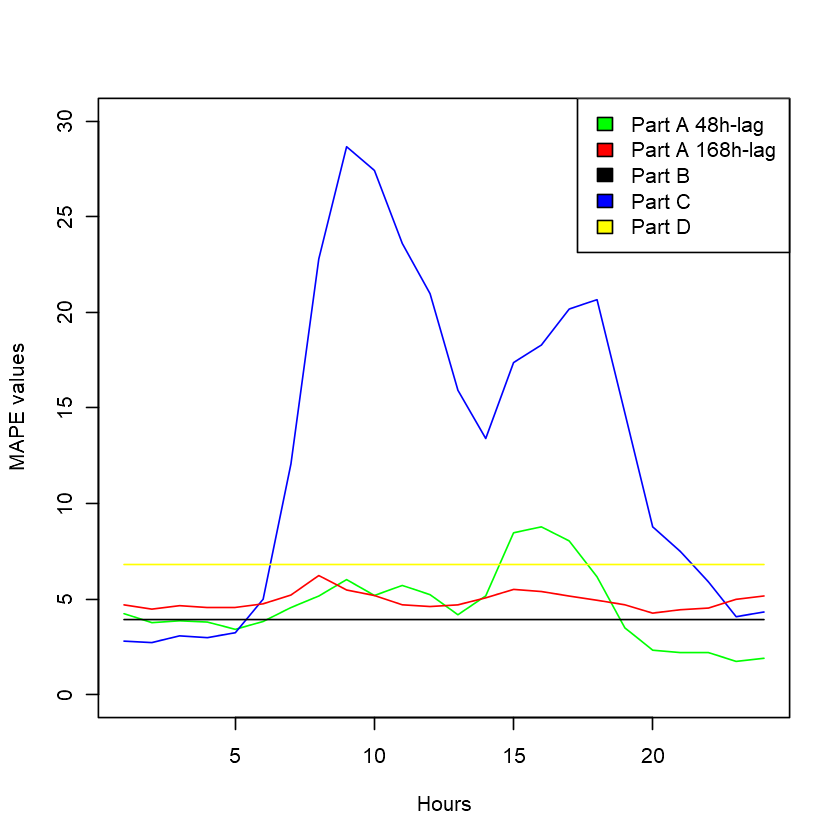

```r
part_b<-as.vector(1:24)
for (i in 1:24){
part_b[i]<-3.92816799427263
}

part_d<-as.vector(1:24)
for (i in 1:24){
part_d[i]<-6.81057725138288
}
plot(MAPE_lag48, col="green", lwd=1, axes=FALSE, xlab="", ylab="", type="l", ylim=c(0,30))
par(new=TRUE)
plot(x, col="blue", lwd=1,axes=FALSE, xlab="", ylab="", type="l",ylim=c(0,30))
par(new=TRUE)
plot(MAPE_lag168, col="red", lwd=1, axes=FALSE, type="l", xlab="", ylab="",ylim=c(0,30))
par(new=TRUE)
plot(part_d, type="l", col="yellow", axes=FALSE, xlab="", ylab="", lwd=1,ylim=c(0,30))
par(new=TRUE)
plot(part_b, type="l", col="black", xlab="Hours", ylab="MAPE values", lwd=1,ylim=c(0,30))

legend("topright", c("Part A 48h-lag", "Part A 168h-lag","Part B", "Part C", "Part D"),fill=c("green","red", "black", "blue", "yellow"))
```

Looking at the MAPE values of the models that are built according to different predictors, the results are as follows:

1-) One can observe that in the first four hours of the day, model that is constructed in the Part C can propose better forecasts compared to the others. The reason can be the values are not so fluctuates in these hours. Additionally, the values during the day fluctuates affected by various reasons including rain, season, holiday, etc.  
2-) During the day, I can use the model that is built in Part b that is trained with all of the data (1399 days). This model proposes constant consumption on the all day but gives less MAPE values.  
3-) After dinner, the electricity consumption values are predicted best with the two days ago consumption values.